# Homework 1

## Stats 102A Lec 3A

## Arlo Alegre

```r
source("805358245_stats102a_hw1.r")
```

## Problem One

### Greatest Common Divisor of Two Numbers

The hint for creating the GCD function is to use the Eucledian algorithm wherein we divide the two numbers and their remainder while repeating the process a couple of timess until we get the greatest common divisor of the two numbers.

Procedure:

1. Input two numbers (a) and (b).
2. Do a check if (a) and (b) are both positive integers.
3. Reassign (a) and (b) to (d) and (e) with (d) being the larger integer
4. Assign (f) as the remainder of (d) divided by (e).
5. Reassign the smaller integer (e) as the new (d) and the remainder (f) as the new (e).
6. Check if (e) is equal to zero. If (e) is not equal to zero, repeat steps 4 - 6 until (e) is zero.

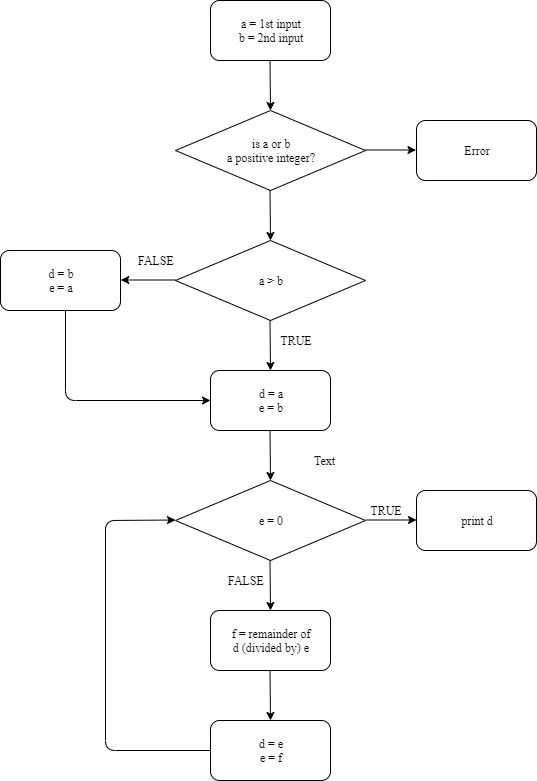

GCD Flowchart

```r
gcd(1071, 462)
```

```
## [1] 21
```

```r
gcd(462, 1071)
```

```
## [1] 21
```

```r
gcd(646, 1406)
```

```
## [1] 38
```

```r
gcd(1, 10)
```

```
## [1] 1
```

```r
try(gcd(0, 12))
```

```
## Error in gcd(0, 12) : You gotta choose positive integers, bruh
```

```r
try(gcd(4.5, 12))
```

```
## Error in gcd(4.5, 12) : You gotta choose positive integers, bruh
```

```r
try(gcd(-1, 12))
```

```
## Error in gcd(-1, 12) : You gotta choose positive integers, bruh
```

### Greatest Common Divisor of Three Numbers

We can use our gcd() function to create our gcd_three() function to find the Greatest Common Divisor of three numbers.

1. Check if all our three numbers are positive integers.
2. Get the gcd of one input and the gcd of two other inputs.

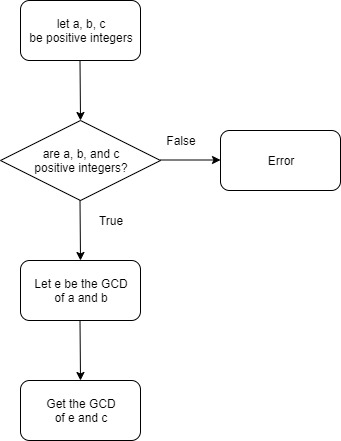

GCD of Three Numbers Flowchart

```r
gcd_three(1071, 462, 4452)
```

```
## [1] 21
```

```r
gcd_three(646, 1406, 4218)
```

```
## [1] 38
```

## Problem Two

### Helper Function

Use the Sieve of Erastothenes to look for the prime factors of our input value. The Sieve of Erastothenes lists all the prime numbers before the input number.

To create the sieve, we have to start with the smalles prime number:

1.Establish an object that would contain a sequence of numbers from 2 to input n. 2. Eliminate all the mupliples of 2 from 2 to our input by assigning the new vector to our object. 3. Use a for-loop to do this all again on the next number on our object that has not been eliminated yet.

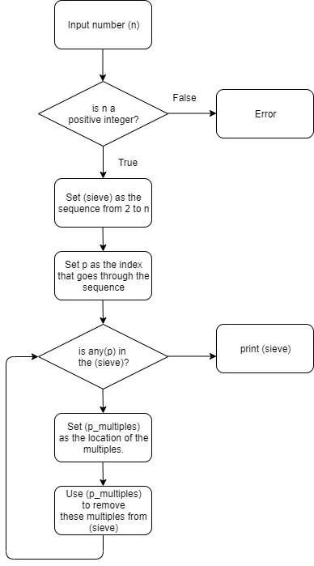

Sieve of Erastothenes Flowchart

Source: Lecture Notes (Michael Tsiang and Guani Wu. 2020. Review of Fundamental Concepts - Chapter 1. Stat 102A Spring 2020. UCLA.)

### Get Factors

We can use the sieve of erastothenes function to create a function that performs prime factorization.

1. We start by making sure our input is a positive integer.
2. we use sieve function to get all the prime numbers less than or equal to our input (x).
3. Then, we can use the “%%” infix function to look for the prime numbers whose remainders are zero when divided to our input number. This only produces the unique prime numbers but not all the factors.
4. We assign y as the product of our factors.
5. We then analyze if (y) = (x).
6. If (y) != (x), we will get the prime numbers of y since this is our new maximum value.
7. Then we create a new object as we repeat step 3 on our (y).
8. Then we reassign our new vector of prime numbers of our (x) as the result of what we got from stpe (3) and the vectors from our step 7.
9. We reassign y as the product of our new vector. Then, we repeat steps 6 - 8 until y = x.
10. When y = x, we can print out our vector of the prime numbers of x. We sort it so it looks better.

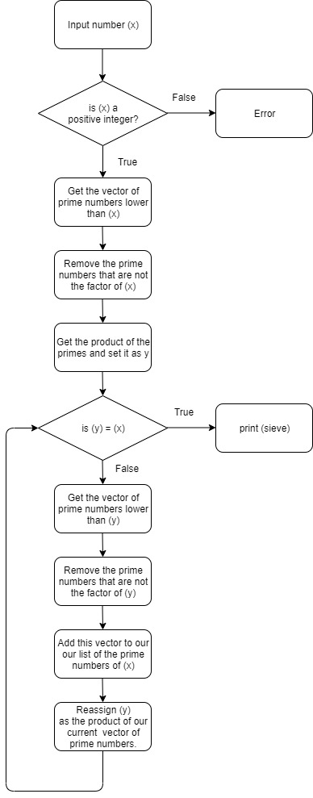

Prime Factorization Flowchart

```r
get_factors(12)
```

```
## [1] 2 2 3
```

```r
get_factors(1800)
```

```
## [1] 2 2 2 3 3 5 5
```

```r
get_factors(9587)
```

```
## [1] 9587
```

```r
try(get_factors(-280))
```

```
## Error in get_factors(-280) : You gotta put a positive integer there, bruh
```

```r
try(get_factors(280.75))
```

```
## Error in get_factors(280.75) :
##   You gotta put a positive integer there, bruh
```

### Is Prime Function

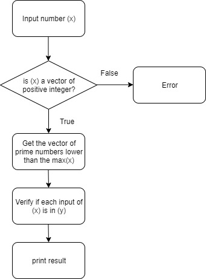

Prime Verification Flowchart

We will also use the sieve of erastothenes for our is_prime function.

1. We will establish y as the sieve of the highest number of our prime numbers list.
2. We will then use the infix function %in% to see if our prime numbers are inside the sieve vector (y). If they are, it will print true for each prime number.

```r
is_prime(9)
```

```
## [1] FALSE
```

```r
is_prime(c(2, 97, 23, 51, 119, -1, 0, 1.5))
```

```
## [1]  TRUE  TRUE  TRUE FALSE FALSE FALSE FALSE FALSE
```

```r
x <- 8757
y <- get_factors(8757)
this_works <- prod(y) == x & all(is_prime(y))
this_works
```

```
## [1] TRUE
```